```r
library(glue)
library(tidyverse)
library(readxl)
```

# Bio-Optical Model

This is a test.

```r
my_aq_site <- "BARC"
my_aop_yr <- "2019"
```

## Reflectance Spectra

```r
spectra_dir <- "/Volumes/hondula/DATA/spectra_buff5m"
spectra_file <- fs::dir_ls(spectra_dir, regexp = glue("{my_aq_site}_{my_aop_yr}"))

spectra_df <- read_csv(spectra_file)
```

```r
my_spectra_pt <- spectra_df %>% filter(my_cellid)

rrs <- spectra_df %>%
  ggplot(aes(wavelength, reflectance)) +
  geom_line(aes(group = cell)) +
  geom_line(data = my_spectra_pt, col = "green", lwd = 1) +
  theme_bw() +
  coord_cartesian(ylim = c(0, 0.1)) +
  theme(legend.position = "none")
```

```r
my_wavelengths_rs <- my_spectra_pt$wavelength
```

## Water Spectra

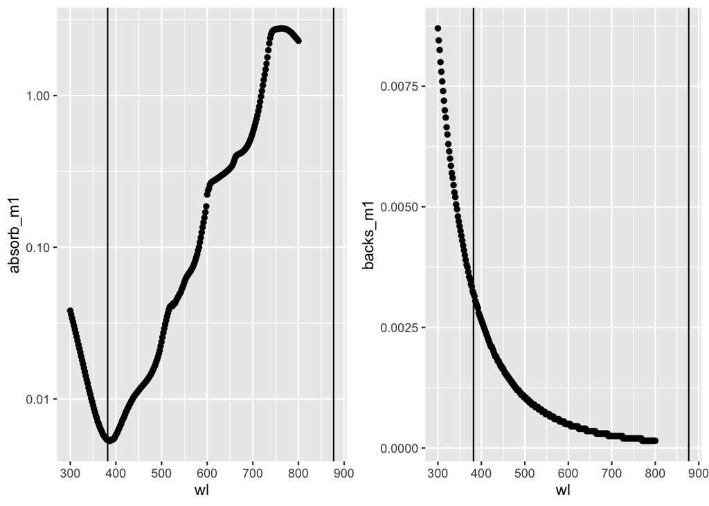

```r
water3 <- read_excel("../../data/water-spectra/water-spectra-buiteveld94.xlsx")

abs_water = data.frame(wl = water3$lambda_nm,
                       absorb_m1 = water3$absorption_m1)

backs_water = data.frame(wl = water3$lambda_nm,
                         backs_m1 = 0.5*(water3$scattering_m1))


aa <- ggplot(abs_water, aes(x = wl, y = absorb_m1)) +
  geom_point() +
  scale_y_log10() +
  # geom_vline(aes(xintercept = 700), col = "red") +
  geom_vline(aes(xintercept = my_wavelengths_rs[1])) +
  geom_vline(aes(xintercept = my_wavelengths_rs[100]))

bb <- ggplot(backs_water, aes(x = wl, y = backs_m1)) +
  geom_point() +
  geom_vline(aes(xintercept = my_wavelengths_rs[1])) +
  geom_vline(aes(xintercept = my_wavelengths_rs[100]))

cowplot::plot_grid(aa, bb)
```

Can only model up to 800 nm based on extent of absorbance and backscattering spectra for water. (More absorbance data in Fewell)

Need to interpolate water spectra to wavelengths of rs data. For now model abs and backs based on water wavelengths

Convert to list so abs_water[[300]] is value?

backscattering coefficient is HALF of scattering coefficient bbw = 0.5*bw bw is scattering coefficient

```r
abs_water_list <- dplyr::select(abs_water, absorb_m1) %>%
  purrr::transpose(.names = glue('wl{abs_water$wl}')) %>%
  purrr::map(~as.numeric(unlist(.x)))
abs_water_list$wl300
```

```
## [1] 0.0382
```

```r
backs_water_list <- dplyr::select(backs_water, backs_m1) %>%
  purrr::transpose(.names = glue('wl{backs_water$wl}')) %>%
  purrr::map(~as.numeric(unlist(.x)))

backs_water_list$wl300
```

```
## [1] 0.0087
```

```r
my_wavelengths_water <- abs_water %>%
  filter(wl %in% seq(range(my_wavelengths_rs)[1], range(my_wavelengths_rs)[2])) %>%
  pull(wl)

backs_water_list[["wl402"]]
```

```
## [1] 0.0026
```

```r
abs_water_list[["wl402"]]
```

```
## [1] 0.0059
```

## Solar zenith angle

```r
zenith_dir <- "/Volumes/hondula/DATA/zenith-angles/"
zenith_file <- fs::dir_ls(zenith_dir, regexp = glue("{my_aq_site}_{my_aop_yr}"))

zenith_df <- read_csv(zenith_file)
```

```r
my_zenith_pt <- zenith_df %>% filter(my_cellid)

# zenith_df %>%
#   ggplot(aes(x = to_sensor_zenith_angle)) +
#   geom_histogram(binwidth = 0.1, col = "black", fill = "gray") +
#   geom_vline(aes(xintercept = my_zenith_pt$to_sensor_zenith_angle), col = "red") +
#   theme_bw()

mu0 <- cos(my_zenith_pt$to_sensor_zenith_angle)
mu0
```

```
## [1] 0.5550638
```

## Flight metadata

Dates of flights

```r
my_aop_dates <- "../neon-sites/results/sites_join_aop_dates.csv" %>%
  readr::read_csv(col_types = "ccccccccddD") %>%
  dplyr::filter(siteID %in% my_aq_site, year %in% my_aop_yr) %>%
  dplyr::select(domanID, siteID, aop_site_id, flightdate) %>%
  distinct()
my_aop_dates
```

```
## # A tibble: 4 x 4
##   domanID siteID aop_site_id flightdate
##   <chr>   <chr>  <chr>       <date>
## 1 D03     BARC   OSBS        2019-04-15
## 2 D03     BARC   OSBS        2019-04-16
## 3 D03     BARC   OSBS        2019-04-21
## 4 D03     BARC   OSBS        2019-04-22
```

Time of pixel acquisition from L1 radiance data

```r
radtimes_dir <- "/Volumes/hondula/DATA/radiance-time/"
radtimes_file <- fs::dir_ls(radtimes_dir, regexp = glue("{my_aq_site}-{my_aop_yr}"))
radtimes_df <- read_csv(radtimes_file) %>% dplyr::filter(!is.na(gps_time))
my_radtime <- radtimes_df$datetime
my_radtime
```

```
## [1] "2019-04-16 18:15:19 UTC"
```

## In situ data

```r
source("R/get-closest-sample.R")
my_analytes <- c("SUVA254", "SUVA280", "doc", "tss", "chla")
my_samps <- my_analytes %>% purrr::map(~get_closest_sample(.x, my_time = my_radtime))
names(my_samps) <- my_analytes

map(my_samps, ~pull(.x, time_diff_days))
```

```
## $SUVA254
## Time difference of -5.1 days
##
## $SUVA280
## Time difference of -5.1 days
##
## $doc
## Time difference of -5.1 days
##
## $tss
## Time difference of -5.1 days
##
## $chla
## Time differences in days
## [1] -55.2 -55.2
```

## Phytoplankton Absorbance

chl conc (mg/L) * specific absorption

chla = sum of chl a AND pheophytin mg/L

specific absorption coefficients from Gege WASI program

Packaging effect: see Equation 2.39 (Bricaud et al 1995)

m2/mg * ug/L = 1/m

```r
chla_df <- my_samps$chla
chla_mgL <- chla_df$analyteConcentration %>% sum()
chla_ugL = chla_mgL/1000

astarPHY <- read_csv("data/gege-wasi-spectra.csv")
```

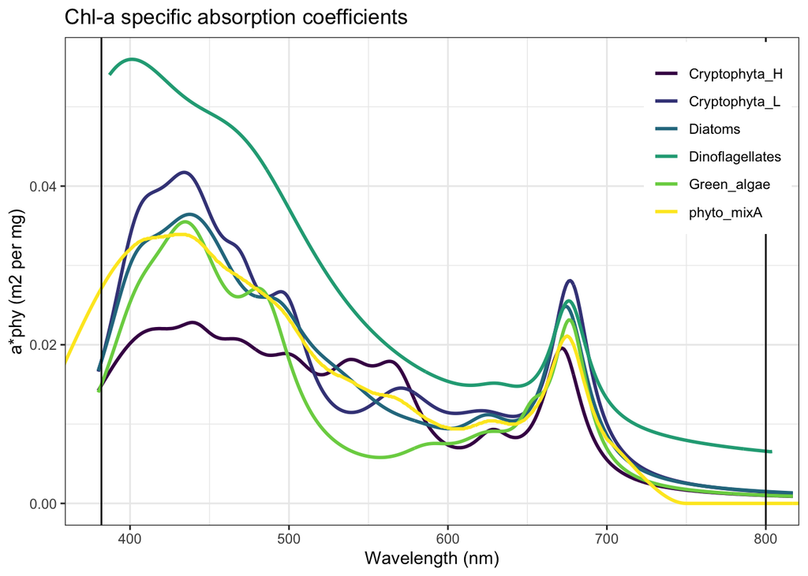

```r
astarPHY %>%
  pivot_longer(cols = 2:7, names_to = "class", values_to = "abs_m2_per_mg") %>%
  ggplot(aes(x = nm, y = abs_m2_per_mg)) +
  geom_line(aes(col = class), lwd = 1) +
  theme_bw() +
  coord_cartesian(xlim = c(380, 800)) +
  theme(legend.title = element_blank()) +
  scale_color_viridis_d() +
  xlab("Wavelength (nm)") +
  ylab("a*phy (m2 per mg)") +
  geom_vline(aes(xintercept = min(my_wavelengths_water))) +
  geom_vline(aes(xintercept = max(my_wavelengths_water))) +
  theme(legend.position = c(0.99,0.99), legend.justification = c(1,1)) +
  ggtitle("Chl-a specific absorption coefficients")
```

Use just phyto_mixA for now

```r
my_wavelengths_water
```

```
##   [1] 382 384 386 388 390 392 394 396 398 400 402 404 406 408 410 412 414 416
##  [19] 418 420 422 424 426 428 430 432 434 436 438 440 442 444 446 448 450 452
##  [37] 454 456 458 460 462 464 466 468 470 472 474 476 478 480 482 484 486 488
##  [55] 490 492 494 496 498 500 502 504 506 508 510 512 514 516 518 520 522 524
##  [73] 526 528 530 532 534 536 538 540 542 544 546 548 550 552 554 556 558 560
##  [91] 562 564 566 568 570 572 574 576 578 580 582 584 586 588 590 592 594 596
## [109] 598 600 602 604 606 608 610 612 614 616 618 620 622 624 626 628 630 632
## [127] 634 636 638 640 642 644 646 648 650 652 654 656 658 660 662 664 666 668
## [145] 670 672 674 676 678 680 682 684 686 688 690 692 694 696 698 700 702 704
## [163] 706 708 710 712 714 716 718 720 722 724 726 728 730 732 734 736 738 740
## [181] 742 744 746 748 750 752 754 756 758 760 762 764 766 768 770 772 774 776
## [199] 778 780 782 784 786 788 790 792 794 796 798 800
```

```r
astarPHY_df <- astarPHY %>%
  dplyr::filter(nm >= min(my_wavelengths_water),
                nm <= max(my_wavelengths_water)) %>%
  dplyr::select(nm, phyto_mixA) %>%
  mutate(abs_phy = phyto_mixA*chla_ugL)

# astarPHY_df %>%
#   ggplot(aes(x = nm, y = abs_phy)) + geom_line()

abs_phy <- astarPHY_df %>%
  dplyr::select(abs_phy) %>%
  purrr::transpose(.names = glue('wl{astarPHY_df$nm}')) %>%
  purrr::map(~as.numeric(unlist(.x)))
```

## CDOM absorbance

eqn 4.1 - absorption coefficient of CDOM

abs[wl] = abs[wlREF] * exp((-SF) * [wl] - [wlREF])

- abs: absorption coefficient (m^-1)
- wl: wavelength (lambda)
- wlREF: reference wavelength commonly 380, 400, 420 or 412, 443 (central wavelength of satellite bands)
- SF: slope factor **indicator of MW, source, etc**

SUVA 254 = abs[254]/DOC absREF is absorbance at reference wavelength

*Slope factor shouldn’t be calculated between 254 and 280 but for logistics assume that absorbance spectra will be determined based on doc and suvas*

```r
cdom_df <- my_samps$doc

my_samps$SUVA254
```

```
## # A tibble: 1 x 13
##   uid             domainID siteID namedLocation  collectDate         analyte
##   <chr>           <chr>    <chr>  <chr>          <dttm>              <chr>
## 1 3da805b1-dacb-… D03      BARC   BARC.AOS.buoy… 2019-04-11 14:42:00 UV Absorba…
## # … with 7 more variables: analyteConcentration <dbl>, analyteUnits <lgl>,
## #   sampleCondition <chr>, loc_type <chr>, time_diff_days <drtn>,
## #   time_diff_abs <drtn>, min_diff <lgl>
```

```r
my_samps$SUVA280
```

```
## # A tibble: 1 x 13
##   uid             domainID siteID namedLocation  collectDate         analyte
##   <chr>           <chr>    <chr>  <chr>          <dttm>              <chr>
## 1 e1fd22f0-076c-… D03      BARC   BARC.AOS.buoy… 2019-04-11 14:42:00 UV Absorba…
## # … with 7 more variables: analyteConcentration <dbl>, analyteUnits <lgl>,
## #   sampleCondition <chr>, loc_type <chr>, time_diff_days <drtn>,
## #   time_diff_abs <drtn>, min_diff <lgl>
```

```r
my_samps$doc
```

```
## # A tibble: 1 x 13
##   uid                 domainID siteID namedLocation  collectDate         analyte
##   <chr>               <chr>    <chr>  <chr>          <dttm>              <chr>
## 1 166b71d5-8f9e-4ef3… D03      BARC   BARC.AOS.buoy… 2019-04-11 14:42:00 DOC
## # … with 7 more variables: analyteConcentration <dbl>, analyteUnits <chr>,
## #   sampleCondition <chr>, loc_type <chr>, time_diff_days <drtn>,
## #   time_diff_abs <drtn>, min_diff <lgl>
```

```r
my_suva254 = my_samps$SUVA254$analyteConcentration
my_suva280 = my_samps$SUVA280$analyteConcentration
my_doc = my_samps$doc$analyteConcentration

abs254 = my_suva254 * my_doc
abs254
```

```
## [1] 0.0835877
```

```r
abs280 = my_suva280 * my_doc
abs280
```

```
## [1] 0.0633156
```

```r
my_doc
```

```
## [1] 2.777
```

```r
my_suva254
```

```
## [1] 0.0301
```

```r
my_suva280
```

```
## [1] 0.0228
```

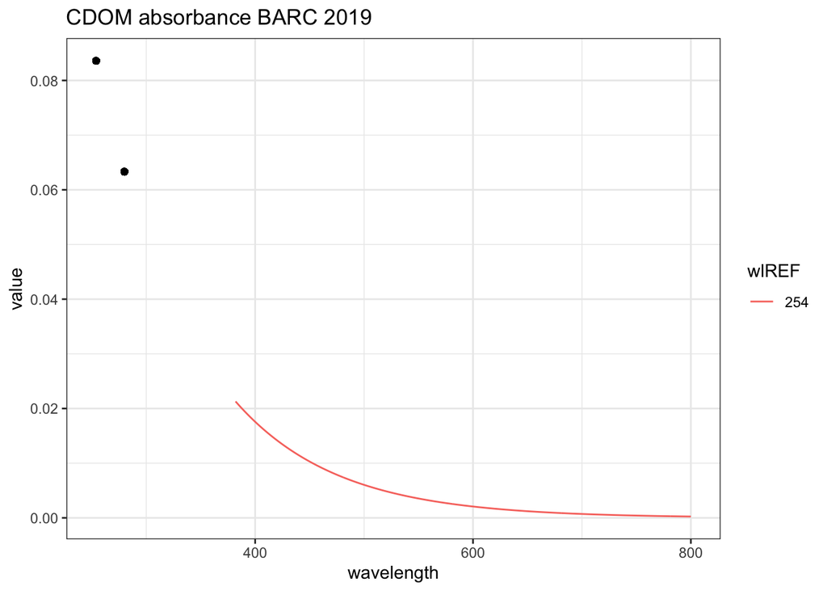

```r
# spectra_min <- min(my_wavelengths_water)
# spectra_max <- max(my_wavelengths_water)

calc_cdom_absorb <- function(wl, absREF, wlREF = 400, SF = 0.0017){
  abs_wl <- absREF * exp(-SF * (wl - wlREF))
  return(abs_wl)
}

calc_cdom_spectra <- function(absREF,
                              spectra_id,
                              spectra_min = min(my_wavelengths_water),
                              spectra_max = max(my_wavelengths_water),
                              wlREF = 400, SF = 0.0017){
  wl_range <- spectra_min:spectra_max
  cdom_spectra <- wl_range %>%
    purrr::map_dbl(~calc_cdom_absorb(.x, absREF, wlREF, SF)) %>%
    as_tibble() %>%
    mutate(wavelength = wl_range) %>%
    mutate(wavelength = as.numeric(wavelength)) %>%
    mutate(spectra_id = spectra_id, wlREF = wlREF, SF = SF)
  return(cdom_spectra)
}

my_sf = log(abs280/abs254)/(-(280-254))

my_spectra <- calc_cdom_spectra(abs254,
                                spectra_min = min(my_wavelengths_water),
                                spectra_max = max(my_wavelengths_water),
                                wlREF = 254,
                                spectra_id = glue("{my_aq_site} {my_aop_yr}"),
                                SF = my_sf)
my_spectra %>%
  mutate(wlREF = forcats::as_factor(wlREF)) %>%
  ggplot(aes(x = wavelength, y = value, group = wlREF)) +
  geom_line(aes(col = wlREF)) +
  geom_point(aes(x = 254, y = abs254)) +
  geom_point(aes(x = 280, y = abs280)) +
  theme_bw() +
  ggtitle(glue("CDOM absorbance {my_aq_site} {my_aop_yr}"))
```

```r
abs_cdom <- dplyr::select(my_spectra, value) %>%
  purrr::transpose(.names = glue('wl{my_spectra$wavelength}')) %>%
  purrr::map(~as.numeric(unlist(.x)))
abs_cdom$wl382
```

```
## [1] 0.02129431
```

## Non-algal suspended matter absorbance

suspended matter conc (mg/L) * specific absorption

mg/L * m2/g = 1/m

```r
bstarSM = 0.0086 # m2 per g
tss_mgL = my_samps$tss$analyteConcentration
tss_mgL
```

```
## [1] 0
```

## Phytoplankton backscattering

```r
chla_df <- my_samps$chla
```

## Non-algal suspended matter backscattering

suspended matter conc (mg/L) * specific backscattering

Constant value of specific backscattering coeffic of suspended matter as per Albert and Mobley 2003, from Lake Constance data

```r
bstarSM = 0.0086 # m2 per g
tss_mgL = my_samps$tss$analyteConcentration
tss_mgL
```

```
## [1] 0
```

```r
backs_sm <- bstarSM*tss_mgL
```

## Model

Equation 4.4 in book

```r
C_mu0 = -0.629 * mu0 + 0.975
surface_factor = 0.544
```

```r
names(abs_water_list)
```

[output not shown]

[output cut: 196 more lines]

```
## wl772
## wl774
## wl776
## wl778
## wl780
## wl782
## wl784
## wl786
## wl788
## wl790
## wl792
## wl794
## wl796
## wl798
## wl800
```

```r
# absorb[] = abs_water_list[] + abs_phyto[] + abs_cdom[] + abs_sm[]
# backs[] = backs_water_list[] + backs_phyto[] + backs_sm[]
# rD[] = 0.544 * C_mu0 * (backs[] / (absorb[] + backs[]))
```

No TSS so ignore for now

Thought I was being fancy with the lists but cant figure out list_merge

```r
names(abs_water_list) %>% length()
```

```
## [1] 251
```

```r
names(abs_phy) %>% length()
```

```
## [1] 419
```

```r
names(abs_cdom) %>% length()
```

```
## [1] 419
```

```r
abs_water_list$wl382
```

```
## [1] 0.0054
```

```r
abs_phy$wl382
```

```
## [1] 5.96706e-05
```

```r
abs_cdom$wl382
```

```
## [1] 0.02129431
```

```r
Awater_df <- flatten_df(abs_water_list) %>%
  tidyr::pivot_longer(cols = 1:251,
                      names_to = "wl", values_to = "abs_water")
Aphy_df <- astarPHY_df %>% dplyr::select(nm, abs_phy) %>%
  mutate(wl = glue("wl{nm}")) %>% dplyr::select(wl, abs_phy)
Acdom_df <- my_spectra %>%
  mutate(wl = glue("wl{wavelength}")) %>%
  dplyr::select(wl, value) %>% rename(abs_cdom = value)

abs_df <- Awater_df %>%
  left_join(Aphy_df, by = c("wl")) %>%
  left_join(Acdom_df, by = c("wl")) %>%
  mutate(abs_total = abs_water + abs_phy + abs_cdom)

Bwater_df <- flatten_df(backs_water_list) %>%
  tidyr::pivot_longer(cols = 1:251,
                      names_to = "wl", values_to = "backs_water")
# Bphy_df <- BstarPHY_df %>% dplyr::select(nm, abs_phy) %>%
#   mutate(wl = glue("wl{nm}")) %>% dplyr::select(wl, abs_phy)

model_df <- abs_df %>%
  left_join(Bwater_df) %>%
  mutate(rD = 0.544 * C_mu0 * (backs_water/ (abs_total + backs_water)))
# absorb[] = abs_water_list[] + abs_phyto[] + abs_cdom[]
# backs[] = backs_water_list[] + backs_phyto[]
# rD[] = 0.544 * C_mu0 * (backs[] / (absorb[] + backs[]))
```

and plot!

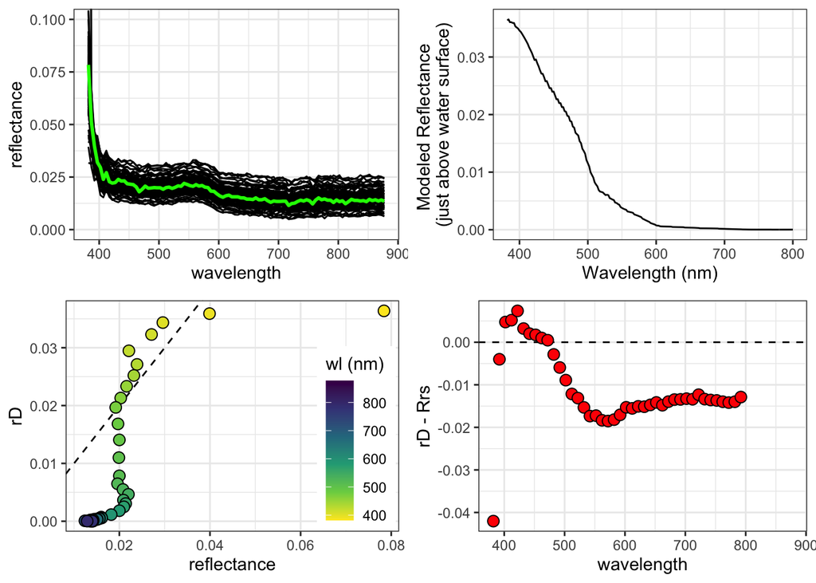

```r
# rrs
model_df2 <- model_df %>%
  mutate(wl = str_replace(wl, "wl", "")) %>%
  mutate(wl = as.numeric(wl)) %>%
  dplyr::filter(wl >= min(my_spectra$wavelength),
                wl <= max(my_spectra$wavelength))

rrd <- model_df2 %>%
  ggplot(aes(x = wl, y = rD)) +
  geom_line() +
  theme_bw() +
  ylab("Modeled Reflectance \n(just above water surface)") +
  xlab("Wavelength (nm)")

ab <- my_spectra_pt %>%
  left_join(model_df2, by = c("wavelength" = "wl")) %>%
  dplyr::select(wavelength, reflectance, rD) %>%
  ggplot(aes(x = reflectance, y = rD)) +
  geom_abline(slope = 1, intercept = 0, lty = 2) +
  geom_point(pch = 21, aes(fill = wavelength), size = 3) +
  scale_fill_viridis_c(direction = -1, name = "wl (nm)") +
  theme_bw() +
  theme(legend.position = c(0.99, 0.01),
        legend.justification = c(1, 0))

ab2 <- my_spectra_pt %>%
  left_join(model_df2, by = c("wavelength" = "wl")) %>%
  dplyr::select(wavelength, reflectance, rD) %>%
  mutate(rD_resid = rD - reflectance) %>%
  ggplot(aes(x = wavelength, y = rD_resid)) +
  geom_hline(aes(yintercept = 0), lty = 2) +
  geom_point(pch = 21, fill = "red", size = 3) +
  ylab("rD - Rrs") +
  theme_bw()

abcd <- cowplot::plot_grid(rrs, rrd, ab, ab2)
abcd
```

```r
# cowplot::save_plot("figs/test-model.png", abcd)
```